# IODS Final project: Attitudes of Finnish eaters

Salla-Maaria Laaksonen salla.laaksonen at helsinki.fi

8 Mar 2017

*Abstract*

The aim of this paper is to identify different behavioural attitudes related to food among Finnish people. The analysis is based on a representative dataset of the Finnish population, collected in 2016. A subset of the questionnaire data consisting of 23 statement variables is explored using principal component analysis. The results show that Finns attitudes towards food and eating can be reasonably depicted using two composite measurements: foodie scale and healthiness scale.

```r
library(foreign)
library(likert)
```

# Introduction

Food plays an important part in our daily routines. Yet food is nothing but ordinary: it is a way people use to express their identity, feelings and build their communities. Therefore different behavioural patterns emerge around our food consumption patterns and food lifestyles.

The aim of this study is to investigate the food consumption attitudes among Finnish people. Methodologically this study resides in the area of quantitative attitude research, where attitudes of the respondents are studied using various statements regarding the studied topic.

# Data and Method

```r
# load the full dataset for the demographic statistics
ss16full <- read.table("ss2016sub-ao.csv", sep=",", header = TRUE, row.names = 1 )
# load the likert dataset for making the likert graphs
ss16likerts <- read.table("ss2016likerts.csv", sep=",", header = TRUE, row.names = 1 )
# load the subset of data with the statement variables only
ss16 <- read.table("ss2016final.csv", sep=",", header = TRUE, row.names = 1 )
```

The data used in this analyses is a dataset called SuomiSyö (“Finland eats”), a survey conducted every year by Taloustutkimus Oy, a Finnish survey company. Odd years to survey is targeted to households and even years to individuals. Data collection method is a paper form. The current data is the most recent set from 2016, hence targeted to individuals. The age and gender of the respondent is available in factors and can be seen below.

```r
summary(ss16full$ika)
```

```
##      20-24 vuotta      25-29 vuotta      30-34 vuotta      35-39 vuotta
##               135               141               124               131
##      40-44 vuotta      45-49 vuotta      50-54 vuotta      55-59 vuotta
##               115               145               191               225
##      60-64 vuotta      65-69 vuotta      70-74 vuotta 75 vuotta tai yli
##               295               336               258               177
##    alle 20 vuotta
##               111
```

```r
summary(ss16full$supu)
```

```
##   mies nainen
##    995   1389
```

The full dataset has 1082 different variables and 2384 respondents. Most of the questions are rather detailed questions about the eating habits of Finnish people. For the purposes of this study only a subset of the variables was selected for the analysis. The selected questions are 23 statement variables that investigate people’s attitude towards food. In addition, due to the requirements of the chosen method, all imcomplete answers were excluded from the analysis, and all variables were transformed to numeric and scaled in order to make variables comparable. See details of the data wrangling [here in the R script](https://github.com/jahapaula/IODS-final/blob/master/ss-wrangling.R).

The list of final selected statements is in Table 1 below.

| Variable | Description |
| --- | --- |
| k1.1 | I want to be a good cook whose food people enjoy |
| k1.2 | Eating is one of life’s greatest pleasures for me |
| k1.3 | Does not really matter what I eat, as long as the hunger goes away |
| k1.4 | Because of time pressure I often skip eating a hot meal |
| k1.5 | On weekdays, I often do not have time to prepare food from the scratch |
| k1.6 | I like to use ready-made foods (eg micro or frozen meals.) |
| k1.7 | For me, ready meals / convenience meals are an important daily food assistance |
| k1.8 | I do not consider myself a skilled cook |
| k1.9 | For me, the meals are important get-together moments for family and friends |
| k1.10 | For me, preparation of homemade food is rewarding |
| k1.11 | I think it’s quite fun to try new things in cooking |
| k1.12 | When I cook, I want it to happen quickly and easily |
| k1.13 | Healthiness of food does not matter to me, because the most important thing is good taste |
| k1.14 | On weekends I put a special effort for cooking |
| k1.15 | I follow the food trends from food blogs / magazines |
| k1.16 | I like to take part in various food events such as Restaurant Day, various food fairs. |
| k1.17 | I put an effort to use fresh raw materials in cooking |
| k1.18 | I would like to eat healthy, above all |
| k1.19 | I often the replace the traditional festive dishes with new options |
| k1.20 | I pay particular attention to the healthiness of raw materials |
| k1.21 | I am not interested in cooking |
| k1.22 | In my opinion, convenience meals contain too many additives (E-codes) |
| k1.23 | Usually I buy as little as possible of processed food |

*Table 1. Variables of the data*

Since this is a large set of statement variables, it is not feasible to start plotting them separately. However, a [likert R package](https://github.com/jbryer/jbryer.github.com/tree/master/likert) made by Jason Bryer makes beautiful graphs that give an overview of the data. Figure 1 below indicates that most of the people who answered this survey seem to agree with statements that express enjoyment towards food and cooking.

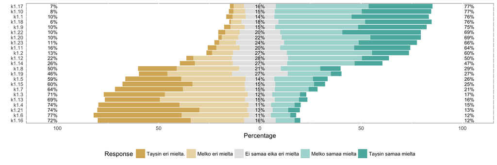

```r
# reorder all factor levels
for(i in c(1:ncol(ss16likerts))) {
  ss16likerts[,i] = factor(ss16likerts[,i],levels(ss16likerts[,i])[c(4,2,1,3,5)])
}

library(likert)
ss16bar <- likert(ss16likerts)
plot(ss16bar)
```

Next, the aim is to reduce the dimensions in this dataset using principal componen analysis (PCA). PCA is a method that investigates the relationships between the variables in the data to produce smaller matrices of them hence unraveling possibly underlying principal components in the data: dimensions that explain the variance of the variables. Through this analysis is it possible to represent the data with lesser dimensions.

# PCA of the statements

The results of the principal componen analysis are represented in Figure 2 below as well as in the summary statistics. PC1 explains 28.11% of the variance in the data, PC2 11.47%, and PC3 8.24%.

```r
# principal component analysis (with the SVD method)
pca_1 <- prcomp(ss16)
summary(pca_1)
```

```
## Importance of components:
##                           PC1    PC2     PC3     PC4     PC5     PC6
## Standard deviation     2.5428 1.6242 1.37688 1.09724 1.00850 0.98114
## Proportion of Variance 0.2811 0.1147 0.08243 0.05235 0.04422 0.04185
## Cumulative Proportion  0.2811 0.3958 0.47824 0.53059 0.57481 0.61666
##                            PC7     PC8     PC9   PC10    PC11    PC12
## Standard deviation     0.94963 0.89895 0.86413 0.8431 0.78350 0.77363
## Proportion of Variance 0.03921 0.03514 0.03247 0.0309 0.02669 0.02602
## Cumulative Proportion  0.65587 0.69100 0.72347 0.7544 0.78106 0.80708
##                           PC13    PC14    PC15    PC16    PC17    PC18
## Standard deviation     0.74562 0.72872 0.70717 0.68252 0.64968 0.62677
## Proportion of Variance 0.02417 0.02309 0.02174 0.02025 0.01835 0.01708
## Cumulative Proportion  0.83126 0.85434 0.87609 0.89634 0.91469 0.93177
##                           PC19    PC20    PC21    PC22    PC23
## Standard deviation     0.61148 0.59367 0.57774 0.50940 0.49959
## Proportion of Variance 0.01626 0.01532 0.01451 0.01128 0.01085
## Cumulative Proportion  0.94803 0.96335 0.97787 0.98915 1.00000
```

```r
pca_1
```

```
## Standard deviations:
##  [1] 2.5427662 1.6242147 1.3768809 1.0972442 1.0085012 0.9811358 0.9496287
##  [8] 0.8989502 0.8641317 0.8430706 0.7834951 0.7736267 0.7456205 0.7287168
## [15] 0.7071722 0.6825242 0.6496841 0.6267734 0.6114844 0.5936689 0.5777410
## [22] 0.5093996 0.4995854
##
## Rotation:
##              PC1         PC2         PC3          PC4          PC5
## k1.1   0.2671205 -0.22269805  0.01157813 -0.032387896  0.227156742
## k1.2   0.1654788 -0.23003524 -0.04158978  0.032604304 -0.028326648
## k1.3  -0.1964738 -0.03096706 -0.01567551 -0.344499935  0.184138564
## k1.4  -0.1343901 -0.17163535 -0.21435123 -0.455975834  0.221462041
## k1.5  -0.1582969 -0.18145493 -0.33933570 -0.219105468  0.084117338
## k1.6  -0.2149263 -0.22108965 -0.35149373  0.173114674  0.084145839
## k1.7  -0.1920263 -0.22498149 -0.37738882  0.214585482  0.117662187
## k1.8  -0.2438300  0.16328963 -0.19484826  0.003881709 -0.109308319
## k1.9   0.2224099 -0.10827998 -0.07242203  0.092484293  0.196461951
## k1.10  0.2804945 -0.14747347  0.01544081 -0.010231761  0.306858451
## k1.11  0.2759232 -0.20218724 -0.03894415 -0.112093460  0.114292617
## k1.12 -0.1672899  0.09241159 -0.26259727 -0.143818396  0.140258556
## k1.13 -0.1403727 -0.32414791  0.19920092 -0.209367848  0.005685944
## k1.14  0.2241161 -0.20700280 -0.07455249 -0.010055328  0.019031516
## k1.15  0.2194374 -0.16849869 -0.21615512 -0.092228800 -0.413203975
## k1.16  0.1653307 -0.17578604 -0.18134810 -0.122809627 -0.569215615
## k1.17  0.2605508  0.13622727 -0.18301227  0.062139613  0.107215680
## k1.18  0.1868504  0.33060980 -0.33418685  0.129837033  0.137356349
## k1.19  0.1554745 -0.02323806 -0.23910631 -0.125030962 -0.302663520
## k1.20  0.2062367  0.31740362 -0.33761390  0.105414064  0.114563171
## k1.21 -0.2758841  0.19947628 -0.10952630 -0.034606242 -0.167415450
## k1.22  0.1187205  0.24783170 -0.01467549 -0.517677882  0.030449127
## k1.23  0.1990671  0.29583910  0.05926260 -0.348099152  0.003987812
##               PC6         PC7         PC8           PC9         PC10
## k1.1  -0.01932591  0.03292616 -0.25878620  0.0490953165 -0.002783295
## k1.2   0.47235688  0.30985383 -0.26429388  0.2834350168  0.213290236
## k1.3  -0.36700823  0.33228357 -0.06514754 -0.2673912052 -0.370282326
## k1.4  -0.16741748 -0.26425034 -0.02357567 -0.2288256564  0.362863301
## k1.5   0.20829700 -0.22357030  0.06280874  0.0214407983  0.329990409
## k1.6  -0.04217838 -0.13217984  0.11423986  0.2736881243 -0.267772514
## k1.7   0.05061470 -0.17151555  0.04624788  0.2286532866 -0.322725460
## k1.8   0.22503601  0.23484344  0.19319157 -0.1766477353 -0.064710434
```

[output cut: 72 more lines]

```
## k1.9   0.163702394 -0.06714352 -0.076369847
## k1.10 -0.597687270  0.02365331  0.062494117
## k1.11  0.438429496  0.04647611 -0.072165346
## k1.12  0.038009045 -0.02276413 -0.066956132
## k1.13  0.024978220  0.11094491 -0.010474528
## k1.14 -0.007383390  0.04004966  0.032844165
## k1.15 -0.123722311 -0.02991748 -0.117837923
## k1.16 -0.006279102  0.02133222  0.059725446
## k1.17  0.038957406 -0.11520052  0.014525419
## k1.18 -0.009154636 -0.46895277  0.379008838
## k1.19 -0.055721576 -0.02586816  0.122158112
## k1.20  0.033978594  0.63753685 -0.416103962
## k1.21 -0.508888701  0.15350669  0.039000425
## k1.22 -0.009787758  0.01462209 -0.019833160
## k1.23  0.058770871 -0.05899308  0.021849139
```

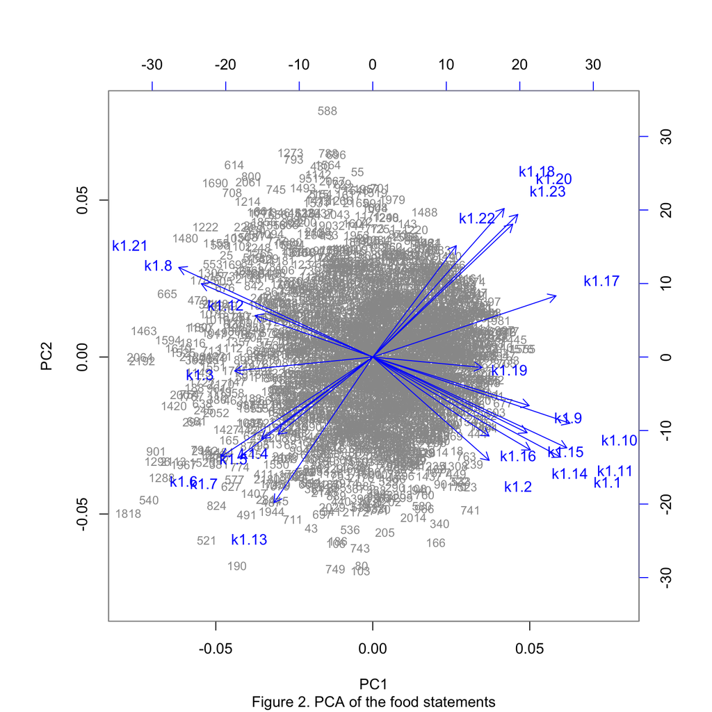

```r
# a biplot of the principal components 1&2 and the original variables
biplot(pca_1, choices = 1:2, cex = c(0.8, 1), col = c("grey60", "blue"), main = " ", sub = "Figure 2. PCA of the food statements")
```

PC1 is loaded with variables that clearly relate to enjoyment related to food on the right side of the graph and variables that describe uninterest towards food and mostly see it as a necessity (see Table 2). This could be named as the foodie dimension: people who score high on this dimension like to cook, try out new things with food, and follow trends and events related to food. Low score people instead consider food only as fuel for their daily activities, and instead of cooking themselves they use convenience food.

| A | Variables describing foodie attitude |
| --- | --- |
| k1.19 | I often the replace the traditional festive dishes with new options |
| k1.9 | For me, the meals are important get-together moments for family and friends |
| k1.10 | For me, preparation of homemade food is rewarding |
| k1.17 | I put an effort to use fresh raw materials in cooking |
| k1.11 | I think it’s quite fun to try new things in cooking |
| k1.1 | I want to be a good cook whose food people enjoy |
| k1.14 | On weekends I put a special effort for cooking |
| k1.15 | I follow the food trends from food blogs / magazines |
| k1.16 | I like to take part in various food events such as Restaurant Day, various food fairs. |
| k1.2 | Eating is one of life’s greatest pleasures for me |
| k1.23 | Usually I buy as little as possible of processed food |
| k1.20 | I pay particular attention to the healthiness of raw materials |
| k1.18 | I would like to eat healthy, above all |
| k1.22 | In my opinion, convenience meals contain too many additives (E-codes) |

| B | Variables describing antifoodie attitude |
| --- | --- |
| k1.3 | Does not really matter what I eat, as long as the hunger goes away |
| k1.4 | Because of time pressure I often skip eating a hot meal |
| k1.5 | On weekdays, I often do not have time to prepare food from the scratch |
| k1.6 | I like to use ready-made foods (eg micro or frozen meals.) |
| k1.7 | For me, ready meals / convenience meals are an important daily food assistance |
| k1.12 | When I cook, I want it to happen quickly and easily |
| k1.8 | I do not consider myself a skilled cook |
| k1.21 | I am not interested in cooking |
| k1.13 | Healthiness of food does not matter to me, because the most important thing is good taste |

*Table 2A&B. Variables describing foodie and antifoodie attitudes.*

PC2, then again, is most loaded with variables k1.18, k1.20 and k1.23 and has a negative loading on variable k1.13. 18,20 and 23 are all related to the importance of healthy choices in food. Statement 13 says “Healthiness of food does not matter to me, because the most important thing is good taste”. Hence, PC2 is a dimension that depicts the interest in a healthy diet.

# Conclusions and discussion

Based on the analysi above we can conclude that a survey of food-related attitudes reveals that two dimension are important describing the attitude of Finns towards food. First dimension was named foodie dimension and it meaures the general interest towards food. Second dimension is a healthiness dimension, which measured the interest towards having a healthy diet.

Further analysis would be needed to identify how are these dimensions represented in the answers of different cohorts of age, sex, and residence area, which could also be done with this data with a little more time.